# Assignment 1B: Unsupervised Learning, Hierarchical Clustering

**Objective**: In this assignment we will use hierarchical clustering to determine customer profiles.

Please do not share this material on any platform or by any other means.

Important Notes:

```
Make changes to the cells that have # YOUR CODE HERE or # YOUR COMMENT HERE.Do not write your answer in anywhere else other than where it says YOUR CODE HERE (or YOUR COMMENT HERE).

Your code must run without any errors start to end. Please go to menubar, select Kernel, and restart the kernel and run all cells (Restart & Run all) before submitting your work.

Purpose of the assignment is to assess your knowledge and command of the data mining algorithm, python programming language, and your ability to resolve common errors. Grading is based on the code and your interpretation/comments you are submitting, not the formatting of the results.

Please use the examples as a guideline, you are not expected to have the same formatting as the example, unless it is a formatting question.
```

Remember, there are many ways to code that can lead to the correct answer, do not hesitate to exercise your own style and python programming coventions.

```python
# Import libraries
import pandas as pd
from sklearn.preprocessing import normalize
import warnings
import seaborn as sns
from scipy.spatial.distance import pdist
from scipy.cluster.hierarchy import dendrogram, linkage, fcluster, cophenet
import matplotlib.pyplot as plt
warnings.filterwarnings('ignore')
```

## Q1: Basic Customer Profiling using Hierarchical Clustering

Customers are the only entities that pay, hence all revolves around the customer. As a data scientist, your objective is to understand the customers who purchase goods from the "Mall" store. How can you get to know your customers and how could this benefit your company?

You are given the "MallCustomers.csv" dataset for this analysis. Start with the steps below, and feel free to research customer profiling online.

1. Analyze, plot and discuss the data
2. Use the "Annual Income (k$) ","Spending Score (1-100) " features, and build a hierarchical clustering model.
3. Evaluate the model results and discuss the performance.
4. Discuss other ways to evaluate the results of your model (not general comments, but specific to your results).
5. Plot the "Annual Income (k$)","Spending Score (1-100)" and use your clustering model predictions to color the customers.
6. Write a short summary of all your findings and your interpretation of the results.

### Analyze, plot and discuss the data

```python
## Fetch the data
customer_data = pd.read_csv('CustomerData-1.csv')
```

```python
## Check the data
customer_data.head(5)
```

|  | CustomerID | Gender | Age | Spending Score (1-100) | Annual Income ($) |
| --- | --- | --- | --- | --- | --- |
| 0 | 1 | Male | 19 | 39 | $15,000.00 |
| 1 | 2 | Male | 21 | 81 | $15,000.00 |
| 2 | 3 | Female | 20 | 6 | $16,000.00 |
| 3 | 4 | Female | 23 | 77 | $16,000.00 |
| 4 | 5 | Female | 31 | 40 | $17,000.00 |

```python
## Check data type and missing values
data_types = customer_data.dtypes
missing_values = customer_data.isnull().sum()

data_types, missing_values
```

```
(CustomerID                 int64
 Gender                    object
 Age                        int64
 Spending Score (1-100)     int64
 Annual Income ($)         object
 dtype: object,
 CustomerID                0
 Gender                    0
 Age                       0
 Spending Score (1-100)    0
 Annual Income ($)         0
 dtype: int64)
```

```python
# Cleaning the 'Annual Income ($)' column
# Removing the dollar sign and commas, and converting it to a float
customer_data['Annual Income ($)'] = customer_data['Annual Income ($)'].replace('[\$,]', '', regex=True).astype(float)

# Convert 'Annual Income ($)' to 'Annual Income (k$)'
customer_data['Annual Income (k$)'] = customer_data['Annual Income ($)'] / 1000

# Selecting the required features
selected_features = customer_data[['Annual Income (k$)', 'Spending Score (1-100)']]

# Display the cleaned data
selected_features.head()
```

|  | Annual Income (k$) | Spending Score (1-100) |
| --- | --- | --- |
| 0 | 15.0 | 39 |
| 1 | 15.0 | 81 |
| 2 | 16.0 | 6 |
| 3 | 16.0 | 77 |
| 4 | 17.0 | 40 |

```python
## Descriptive statistics
summary_statistics = customer_data.describe()
summary_statistics
```

|  | CustomerID | Age | Spending Score (1-100) | Annual Income ($) | Annual Income (k$) |
| --- | --- | --- | --- | --- | --- |
| count | 200.000000 | 200.000000 | 200.000000 | 200.000000 | 200.000000 |
| mean | 100.500000 | 38.850000 | 50.200000 | 60560.000000 | 60.560000 |
| std | 57.879185 | 13.969007 | 25.823522 | 26264.721165 | 26.264721 |
| min | 1.000000 | 18.000000 | 1.000000 | 15000.000000 | 15.000000 |
| 25% | 50.750000 | 28.750000 | 34.750000 | 41500.000000 | 41.500000 |
| 50% | 100.500000 | 36.000000 | 50.000000 | 61500.000000 | 61.500000 |
| 75% | 150.250000 | 49.000000 | 73.000000 | 78000.000000 | 78.000000 |
| max | 200.000000 | 70.000000 | 99.000000 | 137000.000000 | 137.000000 |

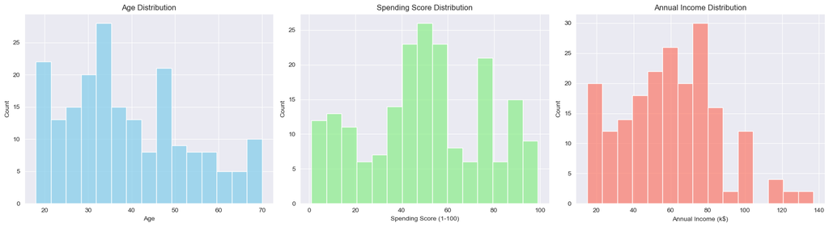

```python
# Creating histograms for Age, Spending Score, and Annual Income
fig, axes = plt.subplots(1, 3, figsize=(18, 5))

# Histogram for Age
sns.histplot(customer_data['Age'], bins=15, ax=axes[0], color='skyblue')
axes[0].set_title('Age Distribution')

# Histogram for Spending Score
sns.histplot(customer_data['Spending Score (1-100)'], bins=15, ax=axes[1], color='lightgreen')
axes[1].set_title('Spending Score Distribution')

# Histogram for Annual Income
sns.histplot(customer_data['Annual Income (k$)'], bins=15, ax=axes[2], color='salmon')
axes[2].set_title('Annual Income Distribution')

plt.tight_layout()
plt.show()
```

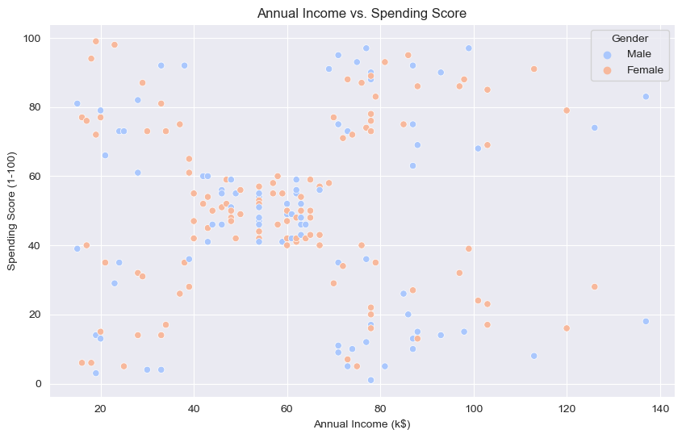

```python
# Scatter plot for Annual Income vs. Spending Score
plt.figure(figsize=(10, 6))
sns.scatterplot(x='Annual Income (k$)', y='Spending Score (1-100)', data=customer_data, hue='Gender', palette='coolwarm')
plt.title('Annual Income vs. Spending Score')
plt.xlabel('Annual Income (k$)')
plt.ylabel('Spending Score (1-100)')
plt.legend(title='Gender')
plt.show()
```

### Build Hierarchical Clustering Model

```python
# Hierarchical clustering
selected_features = customer_data[['Annual Income (k$)', 'Spending Score (1-100)']]

linked = linkage(selected_features, method='ward')
```

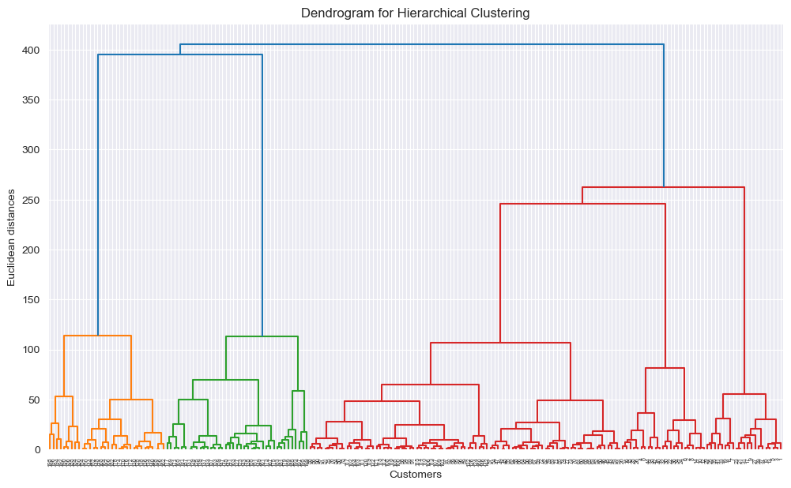

```python
# Plotting the dendrogram
plt.figure(figsize=(12, 7))
dendrogram(linked, orientation='top', distance_sort='descending', show_leaf_counts=True)
plt.title('Dendrogram for Hierarchical Clustering')
plt.xlabel('Customers')
plt.ylabel('Euclidean distances')
plt.show()
```

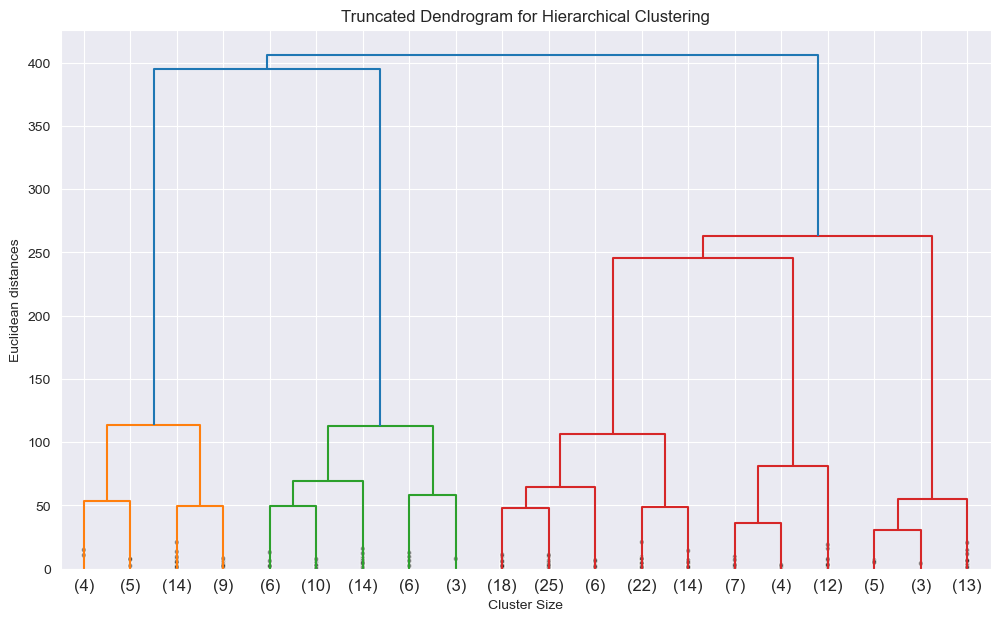

```python
# Plotting a truncated version of the dendrogram
plt.figure(figsize=(12, 7))
dendrogram(linked, orientation='top', truncate_mode='lastp', p=20, show_contracted=True,
           distance_sort='descending', show_leaf_counts=True)
plt.title('Truncated Dendrogram for Hierarchical Clustering')
plt.xlabel('Cluster Size')
plt.ylabel('Euclidean distances')
plt.show()
```

### Evaluate the model results and discuss the performance

```python
# Using fcluster to form flat clusters from the hierarchical clustering
# We can specify the number of clusters directly
flat_clusters = fcluster(linked, t=6, criterion='maxclust')

# Adding flat cluster information to the dataframe
selected_features['Flat Cluster'] = flat_clusters
```

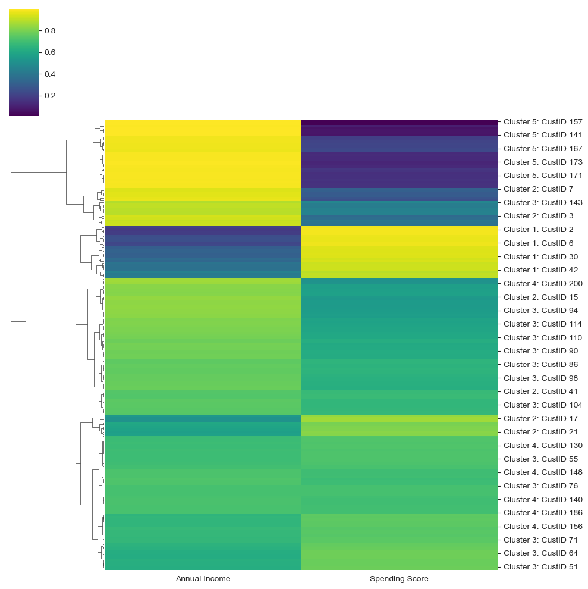

```python
# Normalizing the data
data_normalized = normalize(selected_features[['Annual Income (k$)', 'Spending Score (1-100)']])

# Creating a DataFrame for the normalized data
normalized_df = pd.DataFrame(data_normalized, columns=['Annual Income', 'Spending Score'])

# Adding cluster information again
normalized_df['Cluster'] = flat_clusters

# Setting the index as 'Cluster: CustomerID' format
normalized_df.index = ['Cluster {}: CustID {}'.format(cluster, id) for cluster, id in zip(normalized_df['Cluster'], customer_data['CustomerID'])]

# Dropping the 'Cluster' column as it's now part of the index
normalized_df.drop('Cluster', axis=1, inplace=True)

# Creating the heatmap using clustermap
sns.clustermap(normalized_df, method='average', col_cluster=False, cmap='viridis')
plt.show()
```

The heatmap provides a visual representation of the hierarchical clustering results. Each row in the heatmap corresponds to a customer, labeled with their assigned cluster and CustomerID. The rows are ordered based on hierarchical clustering, grouping similar customers together.

### Other evaluation of model

```python
# Calculating the cophenetic correlation coefficient
cophenetic_corr, coph_dists = cophenet(linked, pdist(selected_features[['Annual Income (k$)', 'Spending Score (1-100)']]))

cophenetic_corr
```

```
0.7179298392392908
```

The cophenetic correlation coefficient for our hierarchical clustering model is approximately 0.718. This value indicates a moderate to high degree of correlation between the cophenetic distances and the actual pairwise distances in the dataset.

- Since the coefficient is closer to 1 than to 0, it suggests that the hierarchical clustering dendrogram reasonably preserves the original distances between pairs of customers in the dataset.
- This means that the clusters formed and their hierarchical relationships are a fairly accurate reflection of the true similarities and differences among customers in terms of their annual income and spending score.

### Cluster visualization

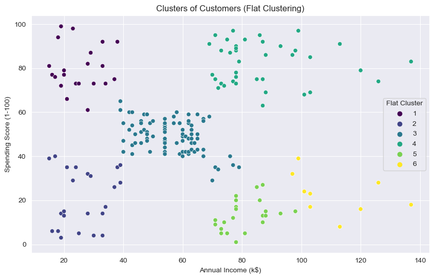

```python
# Plotting the clusters
plt.figure(figsize=(10, 6))
sns.scatterplot(x='Annual Income (k$)', y='Spending Score (1-100)', hue='Flat Cluster', palette='viridis', data=selected_features, legend='full')
plt.title('Clusters of Customers (Flat Clustering)')
plt.xlabel('Annual Income (k$)')
plt.ylabel('Spending Score (1-100)')
plt.legend(title='Flat Cluster')
plt.show()
```

### Summary

There are six cluster mapping in the graph:

- Low Income, Low Spending Score: One cluster likely represents customers with lower income and lower spending scores. This group might be more price-sensitive.
- Low Income, High Spending Score: Another cluster shows customers with lower income but higher spending scores. These customers might be younger or more inclined towards impulse purchases.
- Moderate Income, Moderate Spending Score: There appears to be one or more clusters in the middle range of both income and spending. These could represent the average customers.
- High Income, High Spending Score: There is a distinct cluster for high-income, high-spending customers. This group is often the target for luxury and premium brands.
- High Income, Low Spending Score: Some clusters represent high-income customers with lower spending scores. These individuals might be more conservative with their spending or looking for high-value purchases.
- Special Group (Variable Income, Variable Spending Score): There might be a cluster or clusters that do not fit neatly into the above categories, indicating a group of customers with varied income levels and spending habits.

With six clusters, the analysis can cater to more specific marketing strategies, as it allows for a more granular understanding of different customer behaviors and preferences.

**End of Assignment 1B**